# Simulating a model with MaBoSS

This notebook can be launched using the Docker image of CoLoMoTo: $docker pull colomoto/colomoto-docker:2018-03-31 or by creating a conda environment wuth the following command: $conda create -n colosys -c colomoto ginsim-python pymaboss -c potassco pip install maboss_test To launch this notebook, type the command: $jupyter notebook

```python
%matplotlib inline
import numpy as np
#import matplotlib.pyplot as plt
import seaborn as sns; sns.set()

import ginsim
import biolqm
import maboss
from colomoto_jupyter import tabulate # for fixpoint table display
from itertools import combinations # for iterating over sets
import matplotlib.pyplot as plt # for modifying plots
import pandas as pd # for the visualization of lists of states
```

## GINsim

```python
lqm = biolqm.load("Charite.zginml")
fps = biolqm.fixpoints(lqm)
print(len(fps), "fixpoints")
pd.DataFrame(fps)
```

```
32 fixpoints
```

|  | Proliferation | Senescence | Apoptosis | FGFR | K_N_HRAS | BRAF | MEK | ERK_1_2 | p38 | CHEK1 | MK2 | CDC25B_C | CDC25A | CDK1 | CDK2 | EGFR | JNK | ATR | ATM | CHEK2 | MTORC1 | EIF4EBP1 | TP53 | p21 | CDK4_6 | S6 | AKT | PI3K | MTORC2 | … |
| --- | --- | --- | --- | --- | --- | --- | --- | --- | --- | --- | --- | --- | --- | --- | --- | --- | --- | --- | --- | --- | --- | --- | --- | --- | --- | --- | --- | --- | --- | --- |
| 0 | 0 | 0 | 0 | 0 | 0 | 0 | 0 | 0 | 0 | 0 | 0 | 0 | 0 | 0 | 0 | 0 | 0 | 0 | 0 | 0 | 0 | 1 | 0 | 0 | 0 | 0 | 0 | 0 | 0 | … |
| 1 | 0 | 0 | 0 | 0 | 0 | 0 | 0 | 0 | 1 | 0 | 1 | 0 | 0 | 0 | 0 | 0 | 0 | 0 | 0 | 0 | 1 | 0 | 0 | 0 | 1 | 1 | 1 | 1 | 1 | … |
| 2 | 0 | 0 | 0 | 0 | 0 | 0 | 0 | 0 | 1 | 0 | 1 | 0 | 0 | 0 | 0 | 0 | 0 | 0 | 0 | 0 | 1 | 0 | 0 | 0 | 1 | 1 | 1 | 1 | 1 | … |
| 3 | 0 | 0 | 0 | 0 | 0 | 0 | 0 | 0 | 1 | 0 | 1 | 0 | 0 | 0 | 0 | 0 | 0 | 1 | 1 | 1 | 1 | 0 | 0 | 0 | 1 | 1 | 1 | 1 | 1 | … |
| 4 | 0 | 0 | 0 | 0 | 0 | 0 | 0 | 0 | 1 | 0 | 1 | 0 | 0 | 0 | 0 | 0 | 0 | 1 | 1 | 1 | 1 | 0 | 0 | 0 | 1 | 1 | 1 | 1 | 1 | … |
| 5 | 0 | 0 | 0 | 0 | 1 | 1 | 1 | 0 | 1 | 0 | 1 | 0 | 0 | 0 | 0 | 1 | 0 | 0 | 0 | 0 | 1 | 0 | 0 | 0 | 1 | 1 | 1 | 1 | 1 | … |
| 6 | 0 | 0 | 0 | 0 | 1 | 1 | 1 | 0 | 1 | 0 | 1 | 0 | 0 | 0 | 0 | 1 | 0 | 0 | 0 | 0 | 1 | 0 | 0 | 0 | 1 | 1 | 1 | 1 | 1 | … |
| 7 | 0 | 0 | 0 | 0 | 1 | 1 | 1 | 0 | 1 | 0 | 1 | 0 | 0 | 0 | 0 | 1 | 0 | 1 | 1 | 1 | 1 | 0 | 0 | 0 | 1 | 1 | 1 | 1 | 1 | … |
| 8 | 0 | 0 | 0 | 0 | 1 | 1 | 1 | 0 | 1 | 0 | 1 | 0 | 0 | 0 | 0 | 1 | 0 | 1 | 1 | 1 | 1 | 0 | 0 | 0 | 1 | 1 | 1 | 1 | 1 | … |
| 9 | 0 | 0 | 0 | 1 | 1 | 1 | 1 | 0 | 1 | 0 | 1 | 0 | 0 | 0 | 0 | 0 | 0 | 0 | 0 | 0 | 1 | 0 | 0 | 0 | 1 | 1 | 1 | 1 | 1 | … |
| 10 | 0 | 0 | 0 | 1 | 1 | 1 | 1 | 0 | 1 | 0 | 1 | 0 | 0 | 0 | 0 | 0 | 0 | 0 | 0 | 0 | 1 | 0 | 0 | 0 | 1 | 1 | 1 | 1 | 1 | … |
| 11 | 0 | 0 | 0 | 1 | 1 | 1 | 1 | 0 | 1 | 0 | 1 | 0 | 0 | 0 | 0 | 0 | 0 | 1 | 1 | 1 | 1 | 0 | 0 | 0 | 1 | 1 | 1 | 1 | 1 | … |
| 12 | 0 | 0 | 0 | 1 | 1 | 1 | 1 | 0 | 1 | 0 | 1 | 0 | 0 | 0 | 0 | 0 | 0 | 1 | 1 | 1 | 1 | 0 | 0 | 0 | 1 | 1 | 1 | 1 | 1 | … |
| 13 | 0 | 0 | 0 | 1 | 1 | 1 | 1 | 0 | 1 | 0 | 1 | 0 | 0 | 0 | 0 | 1 | 0 | 0 | 0 | 0 | 1 | 0 | 0 | 0 | 1 | 1 | 1 | 1 | 1 | … |
| 14 | 0 | 0 | 0 | 1 | 1 | 1 | 1 | 0 | 1 | 0 | 1 | 0 | 0 | 0 | 0 | 1 | 0 | 0 | 0 | 0 | 1 | 0 | 0 | 0 | 1 | 1 | 1 | 1 | 1 | … |
| 15 | 0 | 0 | 0 | 1 | 1 | 1 | 1 | 0 | 1 | 0 | 1 | 0 | 0 | 0 | 0 | 1 | 0 | 1 | 1 | 1 | 1 | 0 | 0 | 0 | 1 | 1 | 1 | 1 | 1 | … |
| 16 | 0 | 0 | 0 | 1 | 1 | 1 | 1 | 0 | 1 | 0 | 1 | 0 | 0 | 0 | 0 | 1 | 0 | 1 | 1 | 1 | 1 | 0 | 0 | 0 | 1 | 1 | 1 | 1 | 1 | … |
| 17 | 0 | 0 | 1 | 0 | 0 | 0 | 0 | 0 | 0 | 0 | 0 | 0 | 0 | 0 | 0 | 0 | 0 | 0 | 0 | 0 | 0 | 1 | 0 | 0 | 0 | 0 | 0 | 0 | 0 | … |
| 18 | 0 | 1 | 1 | 0 | 0 | 0 | 0 | 0 | 0 | 1 | 0 | 0 | 0 | 0 | 0 | 0 | 0 | 0 | 0 | 0 | 0 | 1 | 1 | 1 | 0 | 0 | 0 | 0 | 0 | … |
| 19 | 0 | 1 | 1 | 0 | 0 | 0 | 0 | 0 | 0 | 1 | 0 | 0 | 0 | 0 | 0 | 0 | 0 | 0 | 0 | 0 | 0 | 1 | 1 | 1 | 0 | 0 | 0 | 0 | 0 | … |
| 20 | 0 | 1 | 1 | 0 | 0 | 0 | 0 | 0 | 0 | 1 | 0 | 0 | 0 | 0 | 0 | 0 | 1 | 0 | 0 | 0 | 0 | 1 | 1 | 1 | 0 | 0 | 0 | 0 | 0 | … |
| 21 | 0 | 1 | 1 | 0 | 0 | 0 | 0 | 0 | 0 | 1 | 0 | 0 | 0 | 0 | 0 | 0 | 1 | 0 | 0 | 0 | 0 | 1 | 1 | 1 | 0 | 0 | 0 | 0 | 0 | … |
| 22 | 1 | 0 | 0 | 0 | 0 | 0 | 0 | 0 | 0 | 0 | 0 | 0 | 1 | 0 | 1 | 0 | 0 | 0 | 0 | 0 | 0 | 1 | 0 | 0 | 0 | 0 | 0 | 0 | 0 | … |
| 23 | 1 | 0 | 0 | 0 | 0 | 0 | 0 | 0 | 0 | 0 | 0 | 1 | 1 | 1 | 1 | 0 | 0 | 0 | 0 | 0 | 0 | 1 | 0 | 0 | 0 | 0 | 0 | 0 | 0 | … |
| 24 | 1 | 0 | 0 | 0 | 1 | 1 | 1 | 0 | 1 | 0 | 1 | 0 | 0 | 0 | 1 | 1 | 0 | 1 | 1 | 1 | 1 | 0 | 0 | 0 | 0 | 1 | 1 | 1 | 1 | … |
| 25 | 1 | 0 | 0 | 0 | 1 | 1 | 1 | 0 | 1 | 0 | 1 | 0 | 0 | 0 | 1 | 1 | 0 | 1 | 1 | 1 | 1 | 0 | 0 | 0 | 0 | 1 | 1 | 1 | 1 | … |
| 26 | 1 | 0 | 0 | 1 | 1 | 1 | 1 | 0 | 1 | 0 | 1 | 0 | 0 | 0 | 1 | 0 | 0 | 1 | 1 | 1 | 1 | 0 | 0 | 0 | 0 | 1 | 1 | 1 | 1 | … |
| 27 | 1 | 0 | 0 | 1 | 1 | 1 | 1 | 0 | 1 | 0 | 1 | 0 | 0 | 0 | 1 | 0 | 0 | 1 | 1 | 1 | 1 | 0 | 0 | 0 | 0 | 1 | 1 | 1 | 1 | … |
| 28 | 1 | 0 | 0 | 1 | 1 | 1 | 1 | 0 | 1 | 0 | 1 | 0 | 0 | 0 | 1 | 1 | 0 | 1 | 1 | 1 | 1 | 0 | 0 | 0 | 0 | 1 | 1 | 1 | 1 | … |
| 29 | 1 | 0 | 0 | 1 | 1 | 1 | 1 | 0 | 1 | 0 | 1 | 0 | 0 | 0 | 1 | 1 | 0 | 1 | 1 | 1 | 1 | 0 | 0 | 0 | 0 | 1 | 1 | 1 | 1 | … |
| 30 | 1 | 0 | 1 | 0 | 0 | 0 | 0 | 0 | 0 | 0 | 0 | 0 | 1 | 0 | 1 | 0 | 0 | 0 | 0 | 0 | 0 | 1 | 0 | 0 | 0 | 0 | 0 | 0 | 0 | … |
| 31 | 1 | 0 | 1 | 0 | 0 | 0 | 0 | 0 | 0 | 0 | 0 | 1 | 1 | 1 | 1 | 0 | 0 | 0 | 0 | 0 | 0 | 1 | 0 | 0 | 0 | 0 | 0 | 0 | 0 | … |

```python
# Getting the list of nodes
nodes = list(fps[0].keys())

# Building a 2D numpy array with the nodes order defined above, with each fixpoint value
data = np.array([[fp[node] for node in nodes] for fp in fps])

# The array is XX fixpoints * XX nodes
data.shape

from sklearn.decomposition import PCA
pca = PCA(n_components=2)
pca.fit(data)

# Getting the new coordinates
X_pca = pca.transform(data)
```

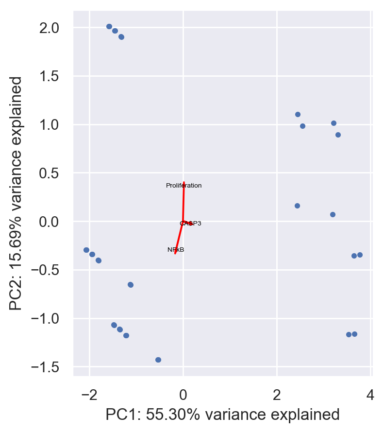

```python
# Plotting the steady states
plt.figure(figsize=(4, 5), dpi=200)
plt.plot(X_pca[:, 0], X_pca[:, 1], ".")

# Printing arrows, but there is too much. We need to select some nodes
#some_nodes = ["EGFR", "TP53","CDK1"]
some_nodes = ["Proliferation", "CASP3","NFkB"]
for some_node in some_nodes:

    v = pca.components_[0:2, nodes.index(some_node)].T
    plt.arrow(0, 0, v[0], v[1], color='red', width=0.01)
    plt.text(v[0], v[1], some_node, color='black', ha='center', va='center', fontsize=5)


plt.xlabel("PC1: %.2f%% variance explained" % (100*pca.explained_variance_ratio_[0]))
plt.ylabel("PC2: %.2f%% variance explained" % (100*pca.explained_variance_ratio_[1]))
```

Visualize the GINsim network if available

```python
ginsim_WT = ginsim.load("Charite.zginml")
```

```python
ginsim.show(ginsim_WT)
```

[figure not shown]

### Reduced model

```python
lqm_red = biolqm.load("reduced_2.zginml")
fps_red = biolqm.fixpoints(lqm_red)
print(len(fps_red), "fixpoints")
pd.DataFrame(fps_red)
```

```
32 fixpoints
```

|  | Proliferation | Apoptosis | FGFR | K_N_HRAS | BRAF | MEK | ERK_1_2 | p38 | CHEK1 | MK2 | CDC25B_C | CDC25A | CDK1 | EGFR | ATR | ATM | CHEK2 | TP53 | EGF | Wee1 | CASP3 | TGFb | DSB_SSB | TNFR | DNA_repair |
| --- | --- | --- | --- | --- | --- | --- | --- | --- | --- | --- | --- | --- | --- | --- | --- | --- | --- | --- | --- | --- | --- | --- | --- | --- | --- |
| 0 | 0 | 0 | 0 | 0 | 0 | 0 | 0 | 0 | 0 | 0 | 0 | 0 | 0 | 0 | 0 | 0 | 0 | 0 | 0 | 1 | 0 | 0 | 0 | 0 | 0 |
| 1 | 0 | 0 | 0 | 0 | 0 | 0 | 0 | 1 | 0 | 1 | 0 | 0 | 0 | 0 | 0 | 0 | 0 | 0 | 0 | 0 | 0 | 1 | 0 | 0 | 0 |
| 2 | 0 | 0 | 0 | 0 | 0 | 0 | 0 | 1 | 0 | 1 | 0 | 0 | 0 | 0 | 0 | 0 | 0 | 0 | 0 | 0 | 0 | 1 | 0 | 1 | 0 |
| 3 | 0 | 0 | 0 | 0 | 0 | 0 | 0 | 1 | 0 | 1 | 0 | 0 | 0 | 0 | 1 | 1 | 1 | 0 | 0 | 0 | 0 | 1 | 1 | 0 | 0 |
| 4 | 0 | 0 | 0 | 0 | 0 | 0 | 0 | 1 | 0 | 1 | 0 | 0 | 0 | 0 | 1 | 1 | 1 | 0 | 0 | 0 | 0 | 1 | 1 | 1 | 0 |
| 5 | 0 | 0 | 0 | 1 | 1 | 1 | 0 | 1 | 0 | 1 | 0 | 0 | 0 | 1 | 0 | 0 | 0 | 0 | 1 | 0 | 0 | 1 | 0 | 0 | 0 |
| 6 | 0 | 0 | 0 | 1 | 1 | 1 | 0 | 1 | 0 | 1 | 0 | 0 | 0 | 1 | 0 | 0 | 0 | 0 | 1 | 0 | 0 | 1 | 0 | 1 | 0 |
| 7 | 0 | 0 | 0 | 1 | 1 | 1 | 0 | 1 | 0 | 1 | 0 | 0 | 0 | 1 | 1 | 1 | 1 | 0 | 1 | 0 | 0 | 1 | 1 | 0 | 0 |
| 8 | 0 | 0 | 0 | 1 | 1 | 1 | 0 | 1 | 0 | 1 | 0 | 0 | 0 | 1 | 1 | 1 | 1 | 0 | 1 | 0 | 0 | 1 | 1 | 1 | 0 |
| 9 | 0 | 0 | 1 | 1 | 1 | 1 | 0 | 1 | 0 | 1 | 0 | 0 | 0 | 0 | 0 | 0 | 0 | 0 | 0 | 0 | 0 | 1 | 0 | 0 | 0 |
| 10 | 0 | 0 | 1 | 1 | 1 | 1 | 0 | 1 | 0 | 1 | 0 | 0 | 0 | 0 | 0 | 0 | 0 | 0 | 0 | 0 | 0 | 1 | 0 | 1 | 0 |
| 11 | 0 | 0 | 1 | 1 | 1 | 1 | 0 | 1 | 0 | 1 | 0 | 0 | 0 | 0 | 1 | 1 | 1 | 0 | 0 | 0 | 0 | 1 | 1 | 0 | 0 |
| 12 | 0 | 0 | 1 | 1 | 1 | 1 | 0 | 1 | 0 | 1 | 0 | 0 | 0 | 0 | 1 | 1 | 1 | 0 | 0 | 0 | 0 | 1 | 1 | 1 | 0 |
| 13 | 0 | 0 | 1 | 1 | 1 | 1 | 0 | 1 | 0 | 1 | 0 | 0 | 0 | 1 | 0 | 0 | 0 | 0 | 1 | 0 | 0 | 1 | 0 | 0 | 0 |
| 14 | 0 | 0 | 1 | 1 | 1 | 1 | 0 | 1 | 0 | 1 | 0 | 0 | 0 | 1 | 0 | 0 | 0 | 0 | 1 | 0 | 0 | 1 | 0 | 1 | 0 |
| 15 | 0 | 0 | 1 | 1 | 1 | 1 | 0 | 1 | 0 | 1 | 0 | 0 | 0 | 1 | 1 | 1 | 1 | 0 | 1 | 0 | 0 | 1 | 1 | 0 | 0 |
| 16 | 0 | 0 | 1 | 1 | 1 | 1 | 0 | 1 | 0 | 1 | 0 | 0 | 0 | 1 | 1 | 1 | 1 | 0 | 1 | 0 | 0 | 1 | 1 | 1 | 0 |
| 17 | 0 | 1 | 0 | 0 | 0 | 0 | 0 | 0 | 0 | 0 | 0 | 0 | 0 | 0 | 0 | 0 | 0 | 0 | 0 | 1 | 1 | 0 | 0 | 1 | 0 |
| 18 | 0 | 1 | 0 | 0 | 0 | 0 | 0 | 0 | 1 | 0 | 0 | 0 | 0 | 0 | 0 | 0 | 0 | 1 | 0 | 1 | 1 | 0 | 0 | 0 | 1 |
| 19 | 0 | 1 | 0 | 0 | 0 | 0 | 0 | 0 | 1 | 0 | 0 | 0 | 0 | 0 | 0 | 0 | 0 | 1 | 0 | 1 | 1 | 1 | 0 | 0 | 1 |
| 20 | 0 | 1 | 0 | 0 | 0 | 0 | 0 | 0 | 1 | 0 | 0 | 0 | 0 | 0 | 0 | 0 | 0 | 1 | 0 | 1 | 1 | 0 | 0 | 1 | 1 |
| 21 | 0 | 1 | 0 | 0 | 0 | 0 | 0 | 0 | 1 | 0 | 0 | 0 | 0 | 0 | 0 | 0 | 0 | 1 | 0 | 1 | 1 | 1 | 0 | 1 | 1 |
| 22 | 1 | 0 | 0 | 0 | 0 | 0 | 0 | 0 | 0 | 0 | 0 | 1 | 0 | 0 | 0 | 0 | 0 | 0 | 0 | 1 | 0 | 0 | 0 | 0 | 0 |
| 23 | 1 | 0 | 0 | 0 | 0 | 0 | 0 | 0 | 0 | 0 | 1 | 1 | 1 | 0 | 0 | 0 | 0 | 0 | 0 | 0 | 0 | 0 | 0 | 0 | 0 |
| 24 | 1 | 0 | 0 | 1 | 1 | 1 | 0 | 1 | 0 | 1 | 0 | 0 | 0 | 1 | 1 | 1 | 1 | 0 | 1 | 0 | 0 | 0 | 1 | 0 | 0 |
| 25 | 1 | 0 | 0 | 1 | 1 | 1 | 0 | 1 | 0 | 1 | 0 | 0 | 0 | 1 | 1 | 1 | 1 | 0 | 1 | 0 | 0 | 0 | 1 | 1 | 0 |
| 26 | 1 | 0 | 1 | 1 | 1 | 1 | 0 | 1 | 0 | 1 | 0 | 0 | 0 | 0 | 1 | 1 | 1 | 0 | 0 | 0 | 0 | 0 | 1 | 0 | 0 |
| 27 | 1 | 0 | 1 | 1 | 1 | 1 | 0 | 1 | 0 | 1 | 0 | 0 | 0 | 0 | 1 | 1 | 1 | 0 | 0 | 0 | 0 | 0 | 1 | 1 | 0 |
| 28 | 1 | 0 | 1 | 1 | 1 | 1 | 0 | 1 | 0 | 1 | 0 | 0 | 0 | 1 | 1 | 1 | 1 | 0 | 1 | 0 | 0 | 0 | 1 | 0 | 0 |
| 29 | 1 | 0 | 1 | 1 | 1 | 1 | 0 | 1 | 0 | 1 | 0 | 0 | 0 | 1 | 1 | 1 | 1 | 0 | 1 | 0 | 0 | 0 | 1 | 1 | 0 |
| 30 | 1 | 1 | 0 | 0 | 0 | 0 | 0 | 0 | 0 | 0 | 0 | 1 | 0 | 0 | 0 | 0 | 0 | 0 | 0 | 1 | 1 | 0 | 0 | 1 | 0 |
| 31 | 1 | 1 | 0 | 0 | 0 | 0 | 0 | 0 | 0 | 0 | 1 | 1 | 1 | 0 | 0 | 0 | 0 | 0 | 0 | 0 | 1 | 0 | 0 | 1 | 0 |

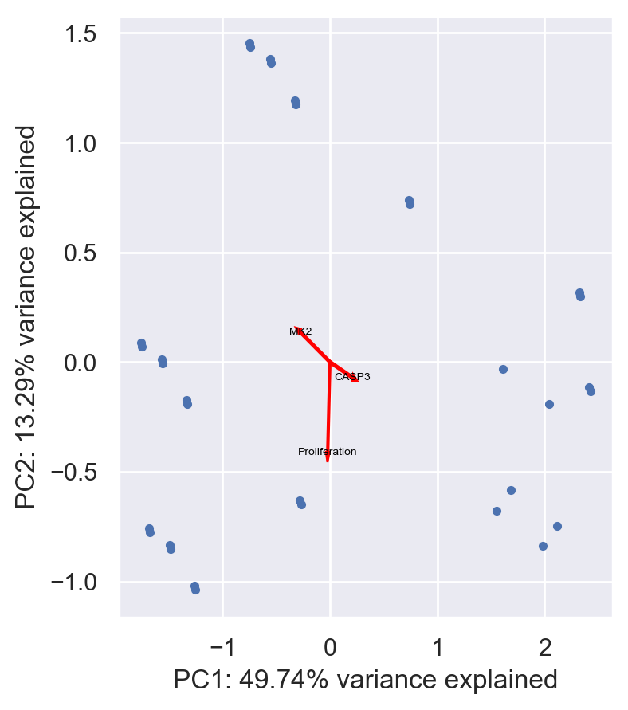

```python
# Getting the list of nodes
nodes = list(fps_red[0].keys())

# Building a 2D numpy array with the nodes order defined above, with each fixpoint value
data = np.array([[fp[node] for node in nodes] for fp in fps_red])

# The array is XX fixpoints * XX nodes
data.shape

from sklearn.decomposition import PCA
pca = PCA(n_components=2)
pca.fit(data)

# Getting the new coordinates
X_pca = pca.transform(data)

# Plotting the steady states
plt.figure(figsize=(4, 5), dpi=200)
plt.plot(X_pca[:, 0], X_pca[:, 1], ".")

# Printing arrows, but there is too much. We need to select some nodes
#some_nodes = ["EGFR", "TP53","CDK1"]
some_nodes = ["Proliferation", "CASP3","MK2"]
for some_node in some_nodes:

    v = pca.components_[0:2, nodes.index(some_node)].T
    plt.arrow(0, 0, v[0], v[1], color='red', width=0.01)
    plt.text(v[0], v[1], some_node, color='black', ha='center', va='center', fontsize=5)


plt.xlabel("PC1: %.2f%% variance explained" % (100*pca.explained_variance_ratio_[0]))
plt.ylabel("PC2: %.2f%% variance explained" % (100*pca.explained_variance_ratio_[1]))
```

```python
ginsim_WT_red = ginsim.load("reduced_2.zginml")
ginsim.show(ginsim_WT_red)
```

[figure not shown]

## MaBoSS simulation of the wild type model

```python
## Set up the required files
bnd_file ="Charite.bnd"
cfg_WT = "Charite.bnd.cfg"
```

Load the model with either all 0s or random initial conditions and modify some configuration parameters. Note that if you used the export of GINsim export, all the initial values will be set to 0

```python
## Load the Wild-Type model
WT = maboss.load(bnd_file, cfg_WT)

## modify the max_time if necessary
## select the variables considered to be internal (not appearing in the resulting csv file)
## run the model for random initial conditions (defined in the cfg file) or from all 0s initial conditions

WT_allinputs = maboss.copy_and_update_parameters(WT, {'max_time':50})

## By default, all variables are external (in the cfg file: Node.is_internal = FALSE).
## If the model is big, the computations may take a very long time.
## We advise to set as external, only the variables that are relevant for the analysis

## if you wish to put some values as internal (the ones that will not be used for the analysis), write (uncomment):
#for name in "ERK_1_2 MK2 p38 Wee1 BRAF CDK1 p21 TP53 Proliferation Senescence Apoptosis".split(' '):
for name in "TAK1 PI3K MTORC2 CDC25A CDK4_6 S6 EIF4EBP1 DNA_repair CHUK JNK AKT p38 p21 HSP27 cPARP CC3".split(' '):
     WT_allinputs.network[name].is_internal = True
```

Select the read-outs from the nodes of the model

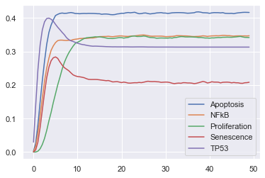

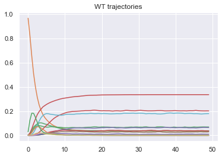

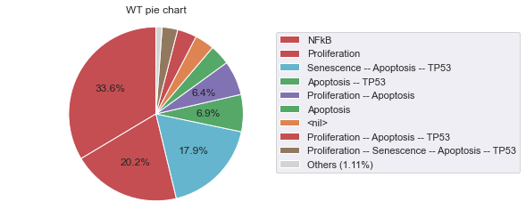

```python
## Select outputs for visualisation of the results
WT_allinputs.network.set_output(('Proliferation','Senescence','Apoptosis','TP53','NFkB'))
#WT_allinputs.network.set_output(('CHEK1','CHEK2','AKT','MEK','NFkB','TP53','ERK_1_2','CASP3'))

WT_allinputs.network.set_istate('FGFR',[0.5,0.5])
WT_allinputs.network.set_istate('EGF',[0.5,0.5])
WT_allinputs.network.set_istate('TGFb',[0.5,0.5])
WT_allinputs.network.set_istate('DSB_SSB',[0.5,0.5])
WT_allinputs.network.set_istate('TNFR',[0.5,0.5])

## Run a MaBoSS simulation
run_WT_allinputs = WT_allinputs.run()

## Plot the results of the WT simulation
run_WT_allinputs.get_nodes_probtraj().plot(legend=True)
run_WT_allinputs.plot_trajectory(legend=False)
plt.title('WT trajectories')
# Plot pie chart
run_WT_allinputs.plot_piechart()
plt.title('WT pie chart')
```

# Simulations of different inputs

We now wish to explore the effect of some input activation on the final probabilities

Set all inputs at 0 to explore the effect of individual input

```python
# Set conditions for simulations

##### Set some nodes to 0 as initial conditions #####
## if all nodes are random and you wish to set only the initial conditions and outputs to 0
#WT_allinputs_random = maboss.copy_and_update_parameters(WT_allinputs, {'max_time':50})
#for name in "Input1 Input2 Input 3 Output 1 Outpu2".split(' '):
#    WT_allinputs0.network.set_istate(name, [1,0])

##### Set all nodes to 0 as initial conditions #####
## if you wish to set, for all nodes of the network, the initial state to 0:
# for n in WT.network:
#    WT_allinputs0.network.set_istate(n,[1,0])

#WT_allinputs_random.network.set_output(('BRAF','CDK1','CASP3'))
#WT_allinputs.network.set_output(('Proliferation','Apoptosis','NFkB','Senescence'))

##### Set all nodes random as initial conditions #####
## if the initial state of all nodes of the network are 0 and you wish them to be all random:
#for n in WT.network:
#    WT_allinputs_random.network.set_istate(n,[0.5,0.5])
```

```python
## Run model
#run_WT_allinputs_random = WT_allinputs_random.run()
```

```python
## Visualize the results

## As a pie chart
#run_WT_allinputs_random.plot_piechart()

## Trajectories of node probabilities
#run_WT_allinputs_random.get_nodes_probtraj().plot(legend=True)

## Trajectories of model states
#run_WT_allinputs_random.get_states_probtraj().plot(legend=False)
```

Simulations for different initial conditions as inputs ON

```python
## Model with different initial conditions
#WT_cond1 = WT_allinputs.copy()

## To test combinations of inputs, include all lines
#WT_cond1.network.set_istate('EGF', [0,1])
#WT_cond1.network.set_istate('DSB_SSB', [1,0])
```

```python
## Visualize only the selected phenotypes
#WT_cond1.network.set_output(('Proliferation','Apoptosis','Senescence'))
#run_cond1 = WT_cond1.run()
```

```python
## Plot pie chart
#run_cond1.plot_piechart()

## Plot the trajectories
#run_cond1.get_nodes_probtraj().plot(legend=True)
#run_cond1.get_states_probtraj().plot(legend=False)
```

## Mutant simulations

Simulate gain of function

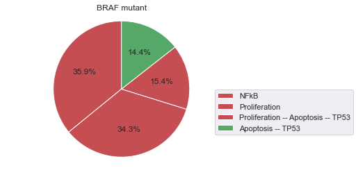

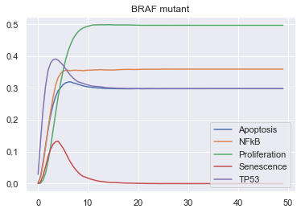

```python
## Visualize only the selected phenotypes
#WT_allinputs.network.set_output(('CHEK1','CHEK2','AKT','MEK','NFkB','TP53','ERK_1_2','CASP3','cPARP'))
#WT_allinputs.network.set_output(('CDK1', 'CDK2','CASP3','NFkB','EGFR','TP53','MK2','CHEK1','AKT'))

## Gain of function for node 1
mut_BRAF_ON = WT_allinputs.copy()
mut_BRAF_ON.mutate("BRAF", "ON")
mutres_BRAF_ON = mut_BRAF_ON.run()
mutres_BRAF_ON.plot_piechart()
plt.title('BRAF mutant')
mutres_BRAF_ON.get_nodes_probtraj().plot(legend=True)
plt.title('BRAF mutant')
```

## Drug treatments on BRAF mutated cells

MK2 inhibitors

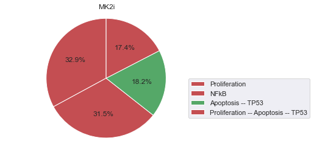

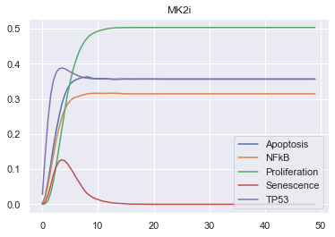

```python
## Inhibition of MK2
mut_MK2i = mut_BRAF_ON.copy()
mut_MK2i.mutate("MK2", "OFF")
mutres_MK2i = mut_MK2i.run()
mutres_MK2i.plot_piechart()
plt.title('MK2i')
mutres_MK2i.get_nodes_probtraj().plot(legend=True)
plt.title('MK2i')
```

CHEK1 inhibitors

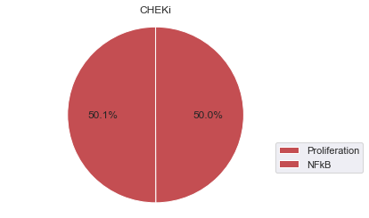

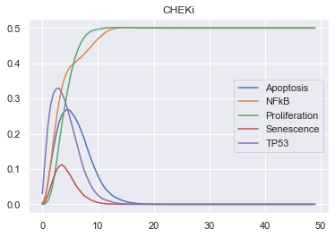

```python
## Inhibition of CHEK1
mut_CHEKi = mut_BRAF_ON.copy()
mut_CHEKi.mutate("CHEK1", "OFF")
#mut_CHEKi.mutate("CHEK2", "OFF")
mutres_CHEKi = mut_CHEKi.run()
mutres_CHEKi.plot_piechart()
plt.title('CHEKi')
mutres_CHEKi.get_nodes_probtraj().plot(legend=True)
plt.title('CHEKi')
```

CHEK1 and MK2 inhibitors

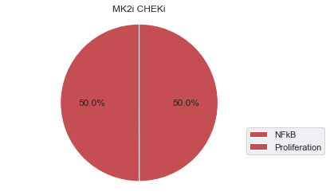

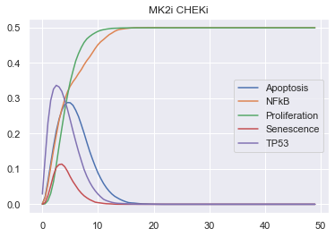

```python
## Inhibition of CHEK1 and MK2
mut_CHEKi = mut_MK2i.copy()
mut_CHEKi.mutate("CHEK1", "OFF")
#mut_CHEKi.mutate("CHEK2", "OFF")
mutres_CHEKi = mut_CHEKi.run()
mutres_CHEKi.plot_piechart()
plt.title('MK2i CHEKi')
mutres_CHEKi.get_nodes_probtraj().plot(legend=True)
plt.title('MK2i CHEKi')
```

## Drug treatments on cell lines

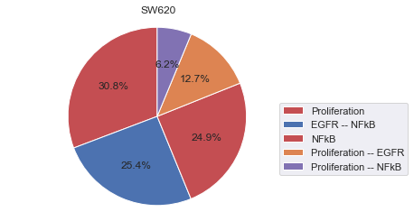

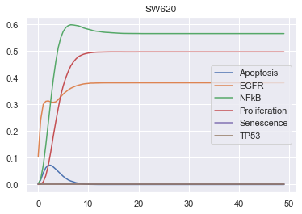

```python
#WT_allinputs.network.set_output(('CHEK1','CHEK2','MEK','TP53','ERK_1_2','CASP3', 'Proliferation','Apoptosis'))
WT_allinputs.network.set_output(('Proliferation','Apoptosis','NFkB','Senescence','TP53','EGFR'))

## SW620 cell lines
mut_SW620 = WT_allinputs.copy()
mut_SW620.mutate("BRAF", "ON")
mut_SW620.mutate("TP53", "OFF")
mutres_SW620 = mut_SW620.run()
mutres_SW620.plot_piechart()
plt.title('SW620')
mutres_SW620.get_nodes_probtraj().plot(legend=True)
plt.title('SW620')
```

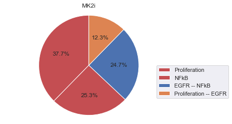

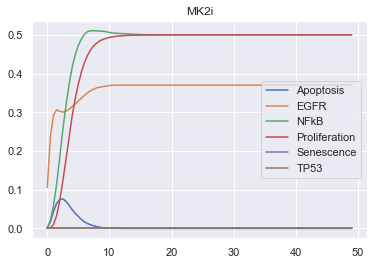

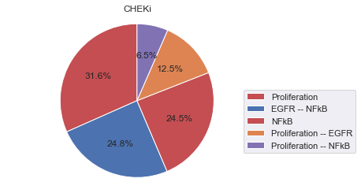

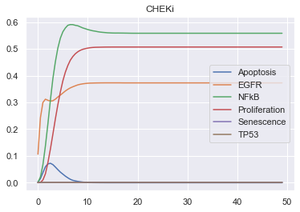

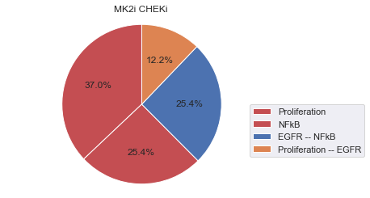

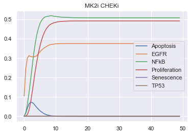

```python
## Visualize only the selected phenotypes
#mut_SW620.network.set_output(('CHEK1','CHEK2','MEK','TP53','ERK_1_2','CASP3', 'Proliferation','Apoptosis'))
mut_SW620.network.set_output(('Proliferation','Apoptosis','NFkB','Senescence','TP53','EGFR'))

#mut_SW620.network.set_output(('Proliferation','CASP3','ERK_1_2'))

## Inhibition of MEK
mut_MK2i = mut_SW620.copy()
mut_MK2i.mutate("MK2", "OFF")
mutres_MK2i = mut_MK2i.run()
mutres_MK2i.plot_piechart()
plt.title('MK2i')
mutres_MK2i.get_nodes_probtraj().plot(legend=True)
plt.title('MK2i')

## Inhibition of CHEK1
mut_CHEKi = mut_SW620.copy()
mut_CHEKi.mutate("CHEK1", "OFF")
mutres_CHEKi = mut_CHEKi.run()
mutres_CHEKi.plot_piechart()
plt.title('CHEKi')
mutres_CHEKi.get_nodes_probtraj().plot(legend=True)
plt.title('CHEKi')

## Inhibition of CHEK1 and MEK
mut_CHEKi = mut_MK2i.copy()
mut_CHEKi.mutate("CHEK1", "OFF")
mutres_CHEKi = mut_CHEKi.run()
mutres_CHEKi.plot_piechart()
plt.title('MK2i CHEKi')
mutres_CHEKi.get_nodes_probtraj().plot(legend=True)
plt.title('MK2i CHEKi')
```

### Model verification

```python
#import maboss
#import maboss_test
#from IPython.display import Image
```

```python
#test = maboss_test.MaBoSSTestCase(mut_SW620)
```

```python
#SW620_Cheki = {'CHEK2':1, 'CASP3':1,'cPARP':1,'ERK_1_2':1, 'MEK':1, 'AKT':1, 'p38':1, 'Proliferation':1, 'NFkB':1, 'TP53':1, 'S6':0}
#SW620_Mk2i = {'CHEK2':1, 'CASP3':1,'cPARP':1,'ERK_1_2':1, 'MEK':1, 'AKT':1, 'p38':1, 'Proliferation':1, 'NFkB':1, 'TP53':1, 'S6':0}
#SW620_Cheki_Mk2i = {'CHEK2':1, 'CASP3':1,'cPARP':1,'ERK_1_2':1, 'MEK':1, 'AKT':1, 'p38':1, 'Proliferation':1, 'NFkB':1, 'TP53':1, 'S6':1}


#SW480_Cheki = {'CHEK2':1, 'CASP3':1,'cPARP':1,'ERK_1_2':1, 'MEK1':1, 'AKT':1, 'p38':1, 'Proliferation':1, 'NFkB':1, 'TP53':1, 'S6':1}
#SW480_Meki = {'CHEK2':1, 'CASP3':1,'cPARP':1,'ERK_1_2':1, 'MEK1':1, 'AKT':1, 'p38':1, 'Proliferation':1, 'NFkB':1, 'TP53':1, 'S6':1}
#SW480_Cheki_Meki = {'CHEK2':1, 'CASP3':1,'cPARP':1,'ERK_1_2':1, 'MEK1':1, 'AKT':1, 'p38':1, 'Proliferation':1, 'NFkB':1, 'TP53':1, 'S6':1}

#HCT116_Cheki = {'CHEK2':1, 'CASP3':1,'cPARP':1,'ERK_1_2':1, 'MEK1':1, 'AKT':1, 'p38':1, 'Proliferation':1, 'NFkB':1, 'TP53':1, 'S6':1}
#HCT116_Meki = {'CHEK2':1, 'CASP3':1,'cPARP':1,'ERK_1_2':1, 'MEK1':1, 'AKT':1, 'p38':1, 'Proliferation':1, 'NFkB':1, 'TP53':1, 'S6':1}
#HCT116_Cheki_Meki = {'CHEK2':1, 'CASP3':1,'cPARP':1,'ERK_1_2':1, 'MEK1':1, 'AKT':1, 'p38':1, 'Proliferation':1, 'NFkB':1, 'TP53':1, 'S6':1}

#Caco2_Cheki = {'CHEK2':1, 'CASP3':1,'cPARP':1,'ERK_1_2':1, 'MEK1':1, 'AKT':1, 'p38':1, 'Proliferation':1, 'NFkB':1, 'TP53':1, 'S6':1}
#Caco2_Meki = {'CHEK2':1, 'CASP3':1,'cPARP':1,'ERK_1_2':1, 'MEK1':1, 'AKT':1, 'p38':1, 'Proliferation':1, 'NFkB':1, 'TP53':1, 'S6':1}
#Caco2_Cheki_Meki = {'CHEK2':1, 'CASP3':1,'cPARP':1,'ERK_1_2':1, 'MEK1':1, 'AKT':1, 'p38':1, 'Proliferation':1, 'NFkB':1, 'TP53':1, 'S6':1}
```

```python
#test.assertStableStateProbabilityEvolution({'CHEK1':'OFF'},{}, 'SW620_Cheki','increase')
#test.assertStableStateProbabilityEvolution({'MK2':'OFF'},{}, SW620_Mk2i,'decrease')
#test.assertStableStateProbabilityEvolution({'CHEK1':'OFF','MK2':'OFF'},{}, SW620_Cheki_Mk2i,'increase')
```

## MaBoSS simulation of the reduced wild type model

```python
## Set up the required files
bnd_file ="reduced_2.bnd"
cfg_WT = "reduced_2.bnd.cfg"
```

```python
## Load the Wild-Type model
WT_red = maboss.load(bnd_file, cfg_WT)

## modify the max_time if necessary
## select the variables considered to be internal (not appearing in the resulting csv file)
## run the model for random initial conditions (defined in the cfg file) or from all 0s initial conditions

WT_red_allinputs = maboss.copy_and_update_parameters(WT_red, {'max_time':50})

## By default, all variables are external (in the cfg file: Node.is_internal = FALSE).
## If the model is big, the computations may take a very long time.
## We advise to set as external, only the variables that are relevant for the analysis

## if you wish to put some values as internal (the ones that will not be used for the analysis), write (uncomment):
#for name in "ERK_1_2 MK2 BRAF CDK1 TP53 Proliferation CASP3 CHEK1 CHEK2 CDC25B_C".split(' '):
#    WT_red_allinputs.network[name].is_internal = True
```

```python
# Select outputs for visualisation of the results
WT_red_allinputs.network.set_output(('Proliferation','NFkB','Apoptosis'))
#WT_red_allinputs.network.set_output(('BRAF','CDK1','TP53'))

WT_red_allinputs.network.set_istate('FGFR',[0.5,0.5])
WT_red_allinputs.network.set_istate('EGF',[0.5,0.5])
WT_red_allinputs.network.set_istate('TGFb',[0.5,0.5])
WT_red_allinputs.network.set_istate('DSB_SSB',[0.5,0.5])
WT_red_allinputs.network.set_istate('TNFR',[0.5,0.5])

## Unit Testing
```

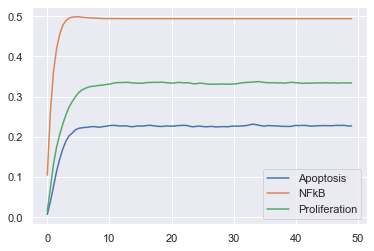

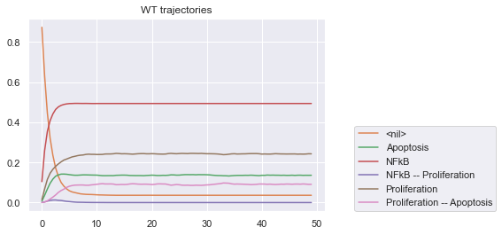

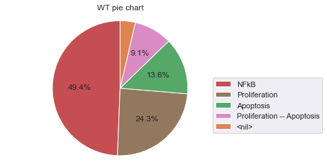

```python
run_WT_red_allinputs = WT_red_allinputs.run()

## Plot the results of the WT simulation
run_WT_red_allinputs.get_nodes_probtraj().plot(legend=True)
run_WT_red_allinputs.plot_trajectory(legend=True)
plt.title('WT trajectories')
# Plot pie chart
run_WT_red_allinputs.plot_piechart()
plt.title('WT pie chart')
```

## CRISPR data - Automatic single mutant simulations

NB: This step needs to be adapted. If you sleect too many nodes, there will be too many plots and the notebook may not handle it.

```python
#import matplotlib.pyplot as plt # for customizing the plots
```

### Simulation of simple inhibition

```python
## If you wish to exclude only some nodes from the all list of variables:
#excluded = set( ('FGFR', 'IGFR', 'EGF', 'DSB_SSB', 'Apoptosis','Proliferation','Senescence', 'HSP27','ROS','ELK_FOS','cPARP','CC3', 'EIF4EBP1','S6','MTORC2') )
#nodes = [ n for n in WT_allinputs.network.names if n not in excluded ]
#nodes.sort()

## if you wish to ony select few nodes:
#nodes = ['Node1','Node2','Node3','Node4']

#WTallinputs.set_output(('Proliferation','Apoptosis', 'NFkB'))
```

```python
# Simulate genes with loss of function
#for mutant in nodes:
#    print(mutant, end=' ')
#    mut_sim = WT_allinputs.copy()
#    mut_sim.mutate(mutant, "OFF")
#    mut_res = mut_sim.run()
#    mut_res.plot_piechart(embed_labels=False, autopct=4)
#    plt.title("%s mutant" % mutant)
```

### Double mutation experiments

```python
# Libraries for creating combinations of mutants
#from itertools import combinations
#from functools import reduce

# Create double mutants
#mutant_combinations = [combinations(m.items(), 2) for m in mutant if len(m) >= 2]
#combinations = reduce(set.union, mutant_combinations, set())
#combinations

# Simulate double mutants
#for mutant in sorted(combinations):
#    mut_sim_double = WT_allinputs.copy()
#    for (node, value) in mutant:
#        mut_sim_double.mutate(node, "ON" if value else "OFF")
#    mut_double_res = mut_sim_double.run()
#    mut_double_res.plot_piechart(embed_labels=False, autopct=4)
#    mutant_name = "/".join(["%s:%s"%m for m in mutant])
#    plt.title("%s mutant" % mutant_name)
```